# Capacity Forecasting and Strategic Insights for Bars, Pubs, Cafes, and Restaurants in Melbourne

### Capacity Forecasting and Strategic Insights for Bars, Pubs, Cafes, and Restaurants in Melbourne

**Authored by:** Venuka Hirushan Wijenayake

**Date:** T2 2024 (July - September)

**Duration:** 270 mins

**Level:** Intermediate

**Pre-requisite Skills:** Python, Machine Learning

### Use Case Scenario

**Title: Capacity Forecasting and Strategic Insights for Bars, Pubs, Cafes, and Restaurants in Melbourne**

**As a** data scientist working with the Melbourne City Planning Department,

**I want to** analyze historical and real-time data on seating capacities and patron trends within Melbourne’s **bars, pubs, cafes, and restaurants**,

**So that I can** identify patterns, predict future capacity requirements, and highlight key areas for potential growth and new hospitality establishments.

**This will help** inform strategic decisions related to zoning, licensing, and infrastructure development to accommodate the city’s evolving hospitality demands. These insights will enhance customer experiences, support business owners, and drive Melbourne's economic growth by ensuring a thriving and balanced hospitality sector.

**By** leveraging predictive models and conducting thorough capacity analysis, I aim to deliver actionable insights that will aid in strategic planning, allowing the city to adapt to future needs while fostering sustainable growth within Melbourne’s hospitality ecosystem.

### Project Goal: Capacity Forecasting and Strategic Insights for Bars, Pubs, Cafes, and Restaurants in Melbourne

Conduct an in-depth analysis of the relationship between the seating capacity of cafes and restaurants and their location within Melbourne. This study aims to develop predictive models that estimate potential seating capacity based on geographic and demographic factors. The ultimate goal is to provide evidence-based recommendations to cafe and restaurant owners for optimizing operations, including location selection, seating arrangement, and marketing strategies. Additionally, the project will offer insights to urban planners to enhance the hospitality landscape in Melbourne, contributing to a more vibrant and economically thriving city.

#### Key Activities

- Data Integration: Combine data from the "Cafes and Restaurants with Seating Capacity" dataset with relevant demographic and geographic data to create a comprehensive dataset for analysis.
- Data Preprocessing: Clean and preprocess the combined dataset to ensure accuracy and relevance for analysis.
- Exploratory Data Analysis: Perform exploratory data analysis to understand the relationships and patterns within the data.
- Predictive Modeling: Develop and validate predictive models to estimate seating capacity based on geographic and demographic factors.
- Visualization and Reporting: Create visualizations and reports to present key findings and recommendations to stakeholders.

#### Expected Outcome

A comprehensive report detailing the relationship between geographic/demographic factors and the seating capacity of cafes and restaurants in Melbourne, with actionable recommendations for optimizing operations. The report will also provide insights for urban planners to enhance Melbourne's hospitality landscape.

#### Impact

This project will empower cafe and restaurant owners to make data-driven decisions, improving operational efficiency and enhancing customer experiences. Urban planners will benefit from insights that support sustainable development and a vibrant hospitality sector in Melbourne, contributing to the city's economic and social vitality.

#### Datasets

*1. Café, restaurant, bistro seats*  
[Link to Dataset 1](https://data.melbourne.vic.gov.au/explore/dataset/cafes-and-restaurants-with-seating-capacity/information/)

*2. Bar, tavern, pub patron capacity*  
[Link to Dataset 2](https://data.melbourne.vic.gov.au/explore/dataset/bars-and-pubs-with-patron-capacity/information/)

## Initialization

### Install all required libraries (Optional)

```python
# pip install requests pandas geopandas folium ipywidgets matplotlib seaborn statsmodels scikit-learn
```

### Importing all the necessory libraries

```python
import warnings
warnings.filterwarnings('ignore')

import requests
import pandas as pd
import geopandas as gpd
import folium
from folium.plugins import MarkerCluster
import ipywidgets as widgets
from IPython.display import display, clear_output

import matplotlib.pyplot as plt
import seaborn as sns
import matplotlib.ticker as mticker

from io import StringIO
from statsmodels.tsa.arima.model import ARIMA

from sklearn.model_selection import train_test_split
from sklearn.ensemble import RandomForestRegressor
from sklearn.metrics import mean_squared_error
```

### Dataset Import Through API

```python
#Function to collect data
def collect_data(dataset_id):
    base_url = 'https://data.melbourne.vic.gov.au/api/explore/v2.1/catalog/datasets/'
    #apikey = api_key #use if use datasets API_key permissions
    dataset_id = dataset_id
    format = 'csv'

    url = f'{base_url}{dataset_id}/exports/{format}'
    params = {
        'select': '*',
        'limit': -1,  # all records
        'lang': 'en',
        'timezone': 'UTC',
        #'api_key': apikey  #use if use datasets API_key permissions
    }

    # GET request
    response = requests.get(url, params=params)

    if response.status_code == 200:
        # StringIO to read the CSV data
        url_content = response.content.decode('utf-8')
        dataset = pd.read_csv(StringIO(url_content), delimiter=';')
        return dataset
    else:
        print(f'Request failed with status code {response.status_code}')
```

### Records Containing in the Datasets

```python
# Set dataset_id to query for the API call dataset name
dataset_id1 = 'bars-and-pubs-with-patron-capacity'
dataset_id2 = 'cafes-and-restaurants-with-seating-capacity'
# Save dataset to df varaible
bars_pubs = collect_data(dataset_id1)
cafes_restaurants = collect_data(dataset_id2)
# Check number of records in df
print(f'The dataset contains {len(bars_pubs)} records.')
print(f'The dataset contains {len(cafes_restaurants)} records.')
```

```
The dataset contains 4696 records.
The dataset contains 60055 records.
```

### Preview the Data

```python
# View the first few rows of each dataset
print("Bars and Pubs Dataset:")
bars_pubs.head(3)
```

```
Bars and Pubs Dataset:
```

|  | census_year | block_id | property_id | base_property_id | building_address | clue_small_area | trading_name | business_address | number_of_patrons | longitude | latitude | location |
| --- | --- | --- | --- | --- | --- | --- | --- | --- | --- | --- | --- | --- |
| 0 | 2002 | 11 | 108972 | 108972 | 10-22 Spencer Street MELBOURNE 3000 | Melbourne (CBD) | Explorers Inn | 10-22 Spencer Street MELBOURNE 3000 | 50 | 144.955254 | -37.820511 | -37.82051068881513, 144.95525416628004 |
| 1 | 2002 | 14 | 103172 | 103172 | 31-39 Elizabeth Street MELBOURNE 3000 | Melbourne (CBD) | Connells Tavern | 35 Elizabeth Street MELBOURNE 3000 | 350 | 144.964322 | -37.817426 | -37.81742610667125, 144.964321660097 |
| 2 | 2002 | 15 | 103944 | 103944 | 277-279 Flinders Lane MELBOURNE 3000 | Melbourne (CBD) | De Biers | Unit 1, Basement , 277 Flinders Lane MELBOURNE... | 400 | 144.965307 | -37.817242 | -37.81724194023457, 144.96530699086 |

```python
print("\nCafes and Restaurants Dataset:")
cafes_restaurants.head(3)
```

```
Cafes and Restaurants Dataset:
```

|  | census_year | block_id | property_id | base_property_id | building_address | clue_small_area | trading_name | business_address | industry_anzsic4_code | industry_anzsic4_description | seating_type | number_of_seats | longitude | latitude | location |
| --- | --- | --- | --- | --- | --- | --- | --- | --- | --- | --- | --- | --- | --- | --- | --- |
| 0 | 2017 | 6 | 578324 | 573333 | 2 Swanston Street MELBOURNE 3000 | Melbourne (CBD) | Transport Hotel | Tenancy 29, Ground , 2 Swanston Street MELBOUR... | 4520 | Pubs, Taverns and Bars | Seats - Indoor | 230 | 144.969942 | -37.817778 | -37.817777826050005, 144.96994164279243 |
| 1 | 2017 | 6 | 578324 | 573333 | 2 Swanston Street MELBOURNE 3000 | Melbourne (CBD) | Transport Hotel | Tenancy 29, Ground , 2 Swanston Street MELBOUR... | 4520 | Pubs, Taverns and Bars | Seats - Outdoor | 120 | 144.969942 | -37.817778 | -37.817777826050005, 144.96994164279243 |
| 2 | 2017 | 11 | 103957 | 103957 | 517-537 Flinders Lane MELBOURNE 3000 | Melbourne (CBD) | Altius Coffee Brewers | Shop , Ground , 517 Flinders Lane MELBOURNE 3000 | 4512 | Takeaway Food Services | Seats - Outdoor | 4 | 144.956486 | -37.819875 | -37.819875445799994, 144.95648638781466 |

## Preprocessing Data

### Displaying available columns

```python
# Print available columns in Bars and Pubs dataset:
print("Available columns in Bars and Pubs dataset:")
print(bars_pubs.columns.tolist())
```

```
Available columns in Bars and Pubs dataset:
['census_year', 'block_id', 'property_id', 'base_property_id', 'building_address', 'clue_small_area', 'trading_name', 'business_address', 'number_of_patrons', 'longitude', 'latitude', 'location']
```

```python
# Print available columns in Cafes and Restaurants dataset:
print("Available columns in Cafes and Restaurants dataset:")
print(cafes_restaurants.columns.tolist())
```

```
Available columns in Cafes and Restaurants dataset:
['census_year', 'block_id', 'property_id', 'base_property_id', 'building_address', 'clue_small_area', 'trading_name', 'business_address', 'industry_anzsic4_code', 'industry_anzsic4_description', 'seating_type', 'number_of_seats', 'longitude', 'latitude', 'location']
```

### Displaying Available Columns

This section displays the column names for both the **Bars and Pubs** and **Cafes and Restaurants** datasets. Understanding the available columns helps in identifying key features that will be used in the analysis and data processing steps.

### Check and Remove Irrelevant Columns

```python
# Columns to remove from each dataset
columns_to_remove_bars_pubs = ['block_id', 'base_property_id', 'clue_small_area', 'business_address', 'latitude', 'longitude']
columns_to_remove_cafes_restaurants = ['block_id', 'base_property_id', 'clue_small_area', 'industry_anzsic4_code', 'business_address', 'latitude', 'longitude']

# Remove irrelevant columns
bars_pubs_updated = bars_pubs.drop(columns=columns_to_remove_bars_pubs)
cafes_restaurants_updated = cafes_restaurants.drop(columns=columns_to_remove_cafes_restaurants)

# Verify remaining columns
print("Remaining columns in Bars and Pubs dataset:")
print(bars_pubs_updated.columns.tolist())

print("Remaining columns in Cafes and Restaurants dataset:")
print(cafes_restaurants_updated.columns.tolist())
```

```
Remaining columns in Bars and Pubs dataset:
['census_year', 'property_id', 'building_address', 'trading_name', 'number_of_patrons', 'location']
Remaining columns in Cafes and Restaurants dataset:
['census_year', 'property_id', 'building_address', 'trading_name', 'industry_anzsic4_description', 'seating_type', 'number_of_seats', 'location']
```

### Check and Remove Irrelevant Columns

In this step, we identify and remove columns that are irrelevant to our analysis from both datasets. This helps streamline the data, focusing only on the necessary features.

#### Columns Removed:

- For **Bars and Pubs**: We removed unnecessary fields such as `'block_id'`, `'base_property_id'`, `'clue_small_area'`, and others.
- For **Cafes and Restaurants**: Similarly, columns like `'block_id'`, `'base_property_id'`, `'industry_anzsic4_code'`, and others were removed.

#### Verification:

After removing the irrelevant columns, the updated datasets were printed to verify the remaining columns that will be used in further analysis.

### Identifying Missing Values

```python
# Check for missing values in the Bars and Pubs dataset
missing_values_bars_pubs = bars_pubs_updated.isnull().sum()
print("Missing values in Bars and Pubs dataset:")
print(missing_values_bars_pubs)

# Check for missing values in the Cafes and Restaurants dataset
missing_values_cafes_restaurants = cafes_restaurants_updated.isnull().sum()
print("Missing values in Cafes and Restaurants dataset:")
print(missing_values_cafes_restaurants)
```

```
Missing values in Bars and Pubs dataset:
census_year           0
property_id           0
building_address      0
trading_name          0
number_of_patrons     0
location             20
dtype: int64
Missing values in Cafes and Restaurants dataset:
census_year                       0
property_id                       0
building_address                  0
trading_name                      0
industry_anzsic4_description      0
seating_type                      0
number_of_seats                   0
location                        527
dtype: int64
```

### Identifying Missing Values

In this step, we check for missing values in both datasets to identify any incomplete data that may require attention during preprocessing.

#### Bars and Pubs Dataset:

We found that the `'location'` column has 20 missing values, while all other columns are complete.

#### Cafes and Restaurants Dataset:

The `'location'` column has 527 missing values, but all other columns are complete.

Identifying these missing values is crucial, as we may need to address them through imputation or removal in order to maintain the quality of our analysis.

### Handle Missing Values in Bars and Pubs Dataset

```python
# Provided latitude and longitude values for the missing data
address_coordinates = {
    "13 Heffernan Lane MELBOURNE 3000": (-37.811798, 144.966599),
    "143-175 Harbour Esplanade DOCKLANDS 3008": (-37.81741, 144.94591),
    "25-27 Rankins Road KENSINGTON 3031": (-37.78929, 144.93211),
    "265-271 Racecourse Road KENSINGTON 3031": (-37.78858, 144.93225),
    "27-45 Whiteman Street SOUTHBANK 3006": (-37.8251819, 144.9582948),
    "353 Little Collins Street MELBOURNE 3000": (-37.8155378, 144.9629855),
    "42-44 Lonsdale Street MELBOURNE 3000": (-37.8097472, 144.9710871),
    "4-6 Goldie Place MELBOURNE 3000": (-37.8132486, 144.9605705),
    "524 Macaulay Road KENSINGTON 3031": (-37.794177, 144.9286062),
    "607-623 Collins Street MELBOURNE 3000": (-37.8190018, 144.9541476),
    "717-731 Collins Street DOCKLANDS 3008": (-37.8149, 144.9505),
    "816 Lorimer Street PORT MELBOURNE 3207": (-37.8221281, 144.9309547),
    "Evan Walker Bridge SOUTHBANK 3006": (-37.8196329, 144.9651296)
}

# Create a copy of the updated DataFrame and name it bars_pubs_cleaned
bars_pubs_cleaned = bars_pubs_updated.copy()

# Update the DataFrame with the provided latitude, longitude, and location values
for address, (lat, lon) in address_coordinates.items():
    bars_pubs_cleaned.loc[bars_pubs_cleaned['building_address'] == address, 'location'] = f"{lat}, {lon}"

# Verify the updated values
print("Updated dataset with filled latitude, longitude, and location:")
print(bars_pubs_cleaned.loc[bars_pubs_cleaned['building_address'].isin(address_coordinates.keys()), ['building_address', 'location']])
```

```
Updated dataset with filled latitude, longitude, and location:
                              building_address                  location
19        42-44 Lonsdale Street MELBOURNE 3000  -37.8097472, 144.9710871
41    353 Little Collins Street MELBOURNE 3000  -37.8155378, 144.9629855
123            4-6 Goldie Place MELBOURNE 3000  -37.8132486, 144.9605705
168            4-6 Goldie Place MELBOURNE 3000  -37.8132486, 144.9605705
229            4-6 Goldie Place MELBOURNE 3000  -37.8132486, 144.9605705
...                                        ...                       ...
4297           4-6 Goldie Place MELBOURNE 3000  -37.8132486, 144.9605705
4302          13 Heffernan Lane MELBOURNE 3000    -37.811798, 144.966599
4341  143-175 Harbour Esplanade DOCKLANDS 3008      -37.81741, 144.94591
4342  143-175 Harbour Esplanade DOCKLANDS 3008      -37.81741, 144.94591
4385           4-6 Goldie Place MELBOURNE 3000  -37.8132486, 144.9605705

[99 rows x 2 columns]
```

### Handle Missing Values in Bars and Pubs Dataset

In this step, we manually fill in the missing location data for specific entries in the **Bars and Pubs** dataset. We provide latitude and longitude coordinates for the missing addresses and update the dataset accordingly.

#### Steps:

1. **Provided Latitude and Longitude Values**: A dictionary of building addresses and their corresponding latitude and longitude values was created.
2. **Data Update**: For each address, the corresponding latitude and longitude values were filled into the `'location'` column of the dataset.
3. **Verification**: After updating the missing values, we verified that the dataset now contains the correct location data for the specified addresses.

This ensures the dataset is complete and accurate, which is important for any location-based analysis or visualizations that will follow.

### Handle Missing Values in Cafes and Restaurants Dataset

```python
# Step 1: Create a mapping of 'building_address' to the most common 'location'
address_to_location_map = cafes_restaurants_updated.groupby('building_address')['location'].agg(lambda x: x.mode().iloc[0] if not x.mode().empty else None)

# Step 2: Fill missing 'location' values using the mapping
cafes_restaurants_updated['location'] = cafes_restaurants_updated.apply(
    lambda row: address_to_location_map[row['building_address']] if pd.isnull(row['location']) else row['location'],
    axis=1
)

# Verify if the missing values are filled
missing_values_after_filling = cafes_restaurants_updated['location'].isnull().sum()
print(f"Missing values in 'location' after filling: {missing_values_after_filling}")
```

```
Missing values in 'location' after filling: 7
```

### Handle Missing Values in Cafes and Restaurants Dataset

In this step, we address missing values in the `'location'` column of the **Cafes and Restaurants** dataset by using existing data.

#### Steps:

1. **Create a Mapping**: We generate a mapping between the `'building_address'` and the most common `'location'` values for each address. This ensures that missing values are replaced with the most likely correct location.
2. **Fill Missing Values**: We then apply this mapping to fill in the missing values in the `'location'` column.
3. **Verification**: After filling in the missing values, we verify that the number of missing values in the `'location'` column has been significantly reduced to 7.

This approach leverages existing data to improve the completeness of the dataset without needing external sources.

### Identify Records with Missing Locations After Update

```python
# Check for missing values in the 'location' column after filling
remaining_missing_locations = cafes_restaurants_updated[cafes_restaurants_updated['location'].isnull()]

# Display the records with missing 'location' values
print("Records with missing 'location' values after update:")
print(remaining_missing_locations)
```

```
Records with missing 'location' values after update:
       census_year  property_id                     building_address  \
21064         2012       101345     0 Flinders Street MELBOURNE 3000
37723         2004       101345     0 Campbell Arcade MELBOURNE 3000
42012         2013       101345     0 Flinders Street MELBOURNE 3000
43223         2002       101345     0 Campbell Arcade MELBOURNE 3000
43789         2003       101345     0 Campbell Arcade MELBOURNE 3000
45008         2004       111240  0 Evan Walker Bridge SOUTHBANK 3006
45711         2005       111240  0 Evan Walker Bridge SOUTHBANK 3006

        trading_name                       industry_anzsic4_description  \
21064   Cup of Truth                             Takeaway Food Services
37723        Jetcall  Internet Service Providers and Web Search Portals
42012   Cup of Truth                             Takeaway Food Services
43223       Bar Rush                             Takeaway Food Services
43789       Bar Rush                             Takeaway Food Services
45008  Clem's Island                             Takeaway Food Services
45711  Clem's Island                             Takeaway Food Services

          seating_type  number_of_seats location
21064   Seats - Indoor                6     None
37723   Seats - Indoor               17     None
42012   Seats - Indoor                6     None
43223   Seats - Indoor               20     None
43789   Seats - Indoor               20     None
45008  Seats - Outdoor               15     None
45711  Seats - Outdoor               15     None
```

### Identify Records with Missing Locations After Update

In this step, we identify the records that still have missing `'location'` values after applying the previous filling methods.

#### Steps:

1. **Check for Missing Values**: We check for any remaining missing values in the `'location'` column to ensure the dataset is as complete as possible.
2. **Display Records**: The remaining records with missing `'location'` values are displayed for further inspection. These records may need additional attention or external data to resolve.

By identifying these incomplete records, we ensure a more thorough cleaning of the dataset, which is critical for accurate analysis.

### Remove Specific Records by Property ID

```python
# Define the Property IDs to remove
property_ids_to_remove = [101345, 111240]

# Remove the rows with the specified Property IDs
cafes_restaurants_updated = cafes_restaurants_updated[~cafes_restaurants_updated['property_id'].isin(property_ids_to_remove)]

# Verify that the records have been removed
print(f"Records after removing Property IDs {property_ids_to_remove}:")
print(cafes_restaurants_updated[cafes_restaurants_updated['property_id'].isin(property_ids_to_remove)])
```

```
Records after removing Property IDs [101345, 111240]:
Empty DataFrame
Columns: [census_year, property_id, building_address, trading_name, industry_anzsic4_description, seating_type, number_of_seats, location]
Index: []
```

### Remove Specific Records by Property ID

In this step, we remove specific records from the **Cafes and Restaurants** dataset based on their `property_id`.

#### Steps:

1. **Define Property IDs**: We specify the `property_id` values that need to be removed.
2. **Remove Records**: Rows with the specified `property_id`s are filtered out of the dataset.
3. **Verify Removal**: After the removal process, we verify that no records with these `property_id`s remain in the dataset.

### De-duplicate Bars and Pubs Data

```python
# Group by 'property_id' and find the index of the row with the maximum 'number_of_patrons' for each group
idx = bars_pubs_cleaned.groupby(['property_id'])['number_of_patrons'].idxmax()

# Use the indices to filter the DataFrame
bars_pubs_deduplicated = bars_pubs_cleaned.loc[idx].reset_index(drop=True)

# Verify the deduplicated DataFrame
print("Deduplicated Bars and Pubs dataset:")
print(bars_pubs_deduplicated.head())
```

```
Deduplicated Bars and Pubs dataset:
   census_year  property_id                            building_address  \
0         2009       100160     196-200 A'Beckett Street MELBOURNE 3000
1         2011       100441  118-126 Ireland Street WEST MELBOURNE 3003
2         2002       100514   204-206 Arden Street NORTH MELBOURNE 3051
3         2005       100727               5-9 Bank Place MELBOURNE 3000
4         2016       100730             12-16 Bank Place MELBOURNE 3000

                                trading_name  number_of_patrons  \
0                Nomads Industry Backpackers                200
1                              Railway Hotel                241
2  North Melbourne Football Club Social Club                210
3                               Mitre Tavern                300
4                      Melbourne Savage Club                 90

                                  location
0      -37.80999191344412, 144.95744282655
1  -37.806072915200005, 144.94210293190025
2    -37.79888820561025, 144.9413101818877
3  -37.816805469325374, 144.96029792995742
4   -37.81654648184162, 144.96058680913345
```

### De-duplicate Bars and Pubs Data

This step involves removing duplicate records from the **Bars and Pubs** dataset by keeping only the row with the highest `'number_of_patrons'` for each unique `property_id`.

#### Steps:

1. **Group by Property ID**: For each `property_id`, we find the row with the maximum number of patrons.
2. **Filter the DataFrame**: Using the indices of these rows, we create a deduplicated version of the dataset.
3. **Verify Deduplication**: The updated dataset is displayed to ensure that only one record per `property_id` remains, with the highest number of patrons retained.

This process ensures that we only retain the most relevant data for further analysis.

### De-duplicate Cafes and Restaurants

```python
# Group by 'property_id' and find the index of the row with the maximum 'number_of_seats' for each group
idx_cafes_restaurants = cafes_restaurants_updated.groupby(['property_id'])['number_of_seats'].idxmax()

# Use the indices to filter the DataFrame and remove duplicates
cafes_restaurants_deduplicated = cafes_restaurants_updated.loc[idx_cafes_restaurants].reset_index(drop=True)

# Verify the deduplicated DataFrame
print("Deduplicated Cafes and Restaurants dataset:")
print(cafes_restaurants_deduplicated.head())
```

```
Deduplicated Cafes and Restaurants dataset:
   census_year  property_id                                building_address  \
0         2002       100041      253 Abbotsford Street NORTH MELBOURNE 3051
1         2002       100084  515-517 Abbotsford Street NORTH MELBOURNE 3051
2         2011       100112  340-348 Abbotsford Street NORTH MELBOURNE 3051
3         2002       100119  218-224 Abbotsford Street NORTH MELBOURNE 3051
4         2017       100153           51-53 A'Beckett Street MELBOURNE 3000

                  trading_name industry_anzsic4_description    seating_type  \
0              Abbot's Seafood       Takeaway Food Services  Seats - Indoor
1           La Dish Fine Foods       Takeaway Food Services  Seats - Indoor
2  Papa Guiseppe Pizza & Pasta       Takeaway Food Services  Seats - Indoor
3             North Star Hotel       Pubs, Taverns and Bars  Seats - Indoor
4            Darac Grill & Bar        Cafes and Restaurants  Seats - Indoor

   number_of_seats                                 location
0                8    -37.80132776477555, 144.9454531679633
1               14   -37.79420437857174, 144.94676212668315
2               16        -37.798727812, 144.94650694307907
3               40  -37.802050792599246, 144.94595697215038
4               44      -37.809095631678616, 144.9620739486
```

### Verify Missing Values

```python
# Check for missing values in each column after deduplication in both datasets

# For Cafes and Restaurants
missing_values_cafes_restaurants = cafes_restaurants_deduplicated.isnull().sum()

# For Bars and Pubs
missing_values_bars_pubs = bars_pubs_deduplicated.isnull().sum()

# Print the number of missing values in each column
print("Missing values in Cafes and Restaurants dataset after deduplication:")
print(missing_values_cafes_restaurants)

print("\nMissing values in Bars and Pubs dataset after deduplication:")
print(missing_values_bars_pubs)
```

```
Missing values in Cafes and Restaurants dataset after deduplication:
census_year                     0
property_id                     0
building_address                0
trading_name                    0
industry_anzsic4_description    0
seating_type                    0
number_of_seats                 0
location                        0
dtype: int64

Missing values in Bars and Pubs dataset after deduplication:
census_year          0
property_id          0
building_address     0
trading_name         0
number_of_patrons    0
location             0
dtype: int64
```

### Verify Missing Values

In this step, we verify whether there are any remaining missing values in both datasets after deduplication.

#### Steps:

1. **Check for Missing Values**: We calculate the number of missing values for each column in both the **Cafes and Restaurants** and **Bars and Pubs** datasets after the deduplication process.
2. **Print Missing Values**: The number of missing values in each column is displayed to confirm that there are no missing values left in the key fields of both datasets.

The results show that both datasets now have zero missing values across all columns, indicating that the datasets are complete and ready for further analysis.

## Exploratory Data Analysis

### Top 20 Bars/Pubs with the Highest Patron Capacity

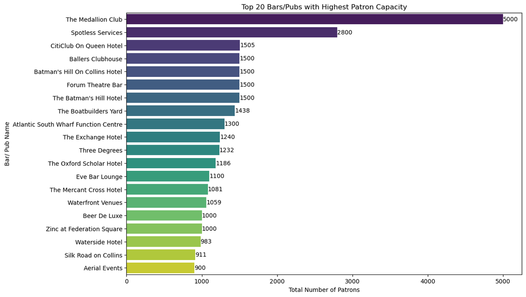

```python
top_20_trading_names = bars_pubs_deduplicated.groupby('trading_name')['number_of_patrons'].sum().nlargest(20).reset_index()

# Create the bar plot
plt.figure(figsize=(12, 8))
bar_plot = sns.barplot(x='number_of_patrons', y='trading_name', data=top_20_trading_names, palette='viridis')

# Add the count on each bar
for index, row in top_20_trading_names.iterrows():
    bar_plot.text(row['number_of_patrons'], index, f'{row["number_of_patrons"]}', va='center')

plt.title('Top 20 Bars/Pubs with Highest Patron Capacity')
plt.xlabel('Total Number of Patrons')
plt.ylabel('Bar/ Pub Name')
plt.show()
```

### Top 20 Bars/Pubs with the Highest Patron Capacity

This visualization displays the top 20 bars and pubs with the highest patron capacity based on the **Bars and Pubs** dataset.

#### Key Points:

- The bars/pubs are ranked by the total number of patrons they can accommodate, with the **Medallion Club** having the highest capacity at 5000 patrons.
- The bar plot clearly shows the variation in capacity, with some locations like **Spotless Services** accommodating 2800 patrons, while others like **Waterfront Venues** host around 1059 patrons.
- The data was grouped by `trading_name`, and the sum of `number_of_patrons` was calculated to determine the largest capacities.

This chart provides insight into which bars and pubs have the highest potential for patronage, which can be useful for business strategy, marketing, or operational planning.

### Top 20 Cafes/ Restaurants with the Highest Seating Capacity

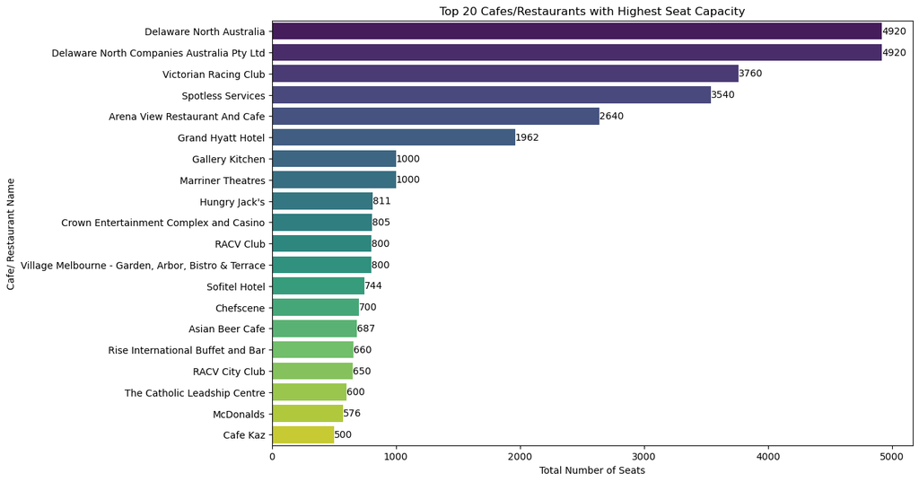

```python
top_20_trading_names = cafes_restaurants_deduplicated.groupby('trading_name')['number_of_seats'].sum().nlargest(20).reset_index()

# Create the bar plot
plt.figure(figsize=(12, 8))
bar_plot = sns.barplot(x='number_of_seats', y='trading_name', data=top_20_trading_names, palette='viridis')

# Add the count on each bar
for index, row in top_20_trading_names.iterrows():
    bar_plot.text(row['number_of_seats'], index, f'{row["number_of_seats"]}', va='center')

plt.title('Top 20 Cafes/Restaurants with Highest Seat Capacity')
plt.xlabel('Total Number of Seats')
plt.ylabel('Cafe/ Restaurant Name')
plt.show()
```

### Top 20 Cafes/Restaurants with the Highest Seating Capacity

This visualization shows the top 20 cafes and restaurants with the highest seating capacity based on the **Cafes and Restaurants** dataset.

#### Key Points:

- The **Delaware North Australia** and **Delaware North Companies Australia Pty Ltd** both lead the chart with a seating capacity of 4920.
- Other significant locations include **Victorian Racing Club** with 3760 seats and **Spotless Services** with 3540 seats.
- The data was grouped by `trading_name`, and the sum of `number_of_seats` was used to determine the largest seating capacities.

This chart provides useful insights into which cafes and restaurants can accommodate the most guests, which can be valuable for planning, resource allocation, and understanding business scale.

### Patrons Distribution

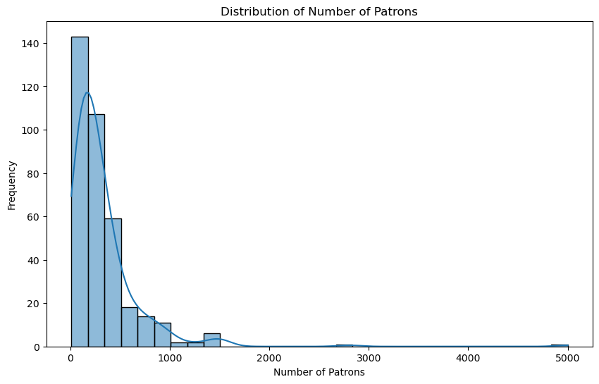

```python
plt.figure(figsize=(10, 6))
sns.histplot(bars_pubs_deduplicated['number_of_patrons'], bins=30, kde=True)
plt.title('Distribution of Number of Patrons')
plt.xlabel('Number of Patrons')
plt.ylabel('Frequency')
plt.show()
```

### Patrons Distribution

This histogram visualizes the distribution of the number of patrons for bars and pubs in the dataset.

#### Key Points:

- The x-axis represents the **Number of Patrons**, while the y-axis represents the **Frequency** (i.e., how many bars/pubs fall into each patron range).
- The majority of bars and pubs accommodate fewer than 500 patrons, with a sharp decline in frequency as the number of patrons increases.
- A kernel density estimate (KDE) line is plotted to provide a smoother representation of the distribution.

This distribution is right-skewed, indicating that while most bars/pubs have a lower capacity, a few have significantly higher patron capacities.

### Box Plot for the Number of Patrons

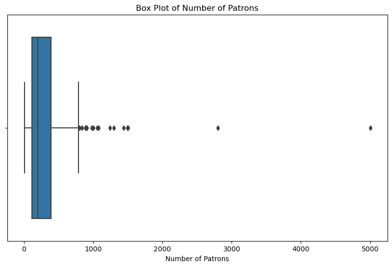

```python
plt.figure(figsize=(10, 6))
sns.boxplot(x=bars_pubs_deduplicated['number_of_patrons'])
plt.title('Box Plot of Number of Patrons')
plt.xlabel('Number of Patrons')
plt.show()
```

### Box Plot for the Number of Patrons

This box plot visualizes the distribution of the number of patrons for bars and pubs, highlighting the spread and any outliers in the dataset.

#### Key Points:

- The **box** represents the interquartile range (IQR), which contains the middle 50% of the data, while the **line** inside the box represents the median number of patrons.
- The **whiskers** extend to show the range of the data excluding outliers.
- Several **outliers** are present beyond the whiskers, with extreme values going as high as 5000 patrons.

This box plot provides a clear picture of how the patron capacities are distributed and where the outliers lie, which helps in understanding the overall variation in the dataset.

### Seating Type Distribution

```
Seating Type Distribution:
seating_type
Seats - Indoor     1702
Seats - Outdoor     167
Name: count, dtype: int64
```

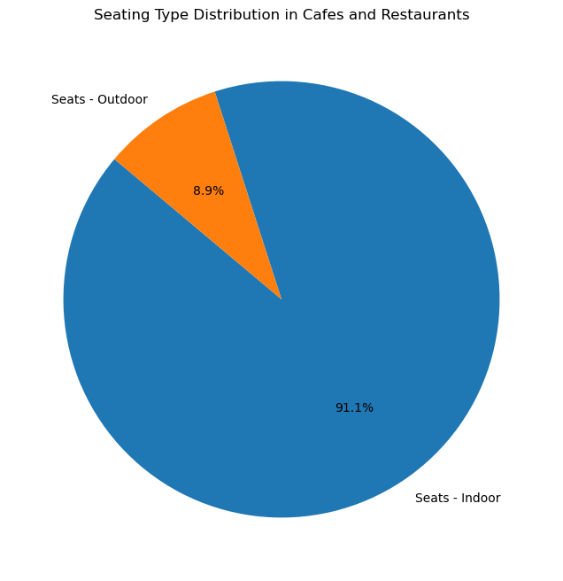

```python
# Group by 'seating_type' and count the number of occurrences
seating_type_counts = cafes_restaurants_deduplicated['seating_type'].value_counts()

# Display the counts
print("Seating Type Distribution:")
print(seating_type_counts)

# Pie chart for seating type distribution
plt.figure(figsize=(8, 8))
plt.pie(seating_type_counts, labels=seating_type_counts.index, autopct='%1.1f%%', startangle=140)
plt.title('Seating Type Distribution in Cafes and Restaurants')
plt.show()
```

### Seating Type Distribution

This pie chart shows the distribution of seating types in the **Cafes and Restaurants** dataset.

#### Key Points:

- **Seats - Indoor** make up the majority, accounting for **91.1%** of the total seating types.
- **Seats - Outdoor** represent **8.9%** of the seating types.

The pie chart provides a clear visual representation of how seating is predominantly indoors in cafes and restaurants, with outdoor seating being much less common.

### Top 5 Industry Distribution

```
Top 5 Industry (ANZSIC4) Descriptions:
industry_anzsic4_description
Cafes and Restaurants     1399
Pubs, Taverns and Bars     164
Takeaway Food Services     147
Accommodation               67
Clubs (Hospitality)         11
Name: count, dtype: int64
```

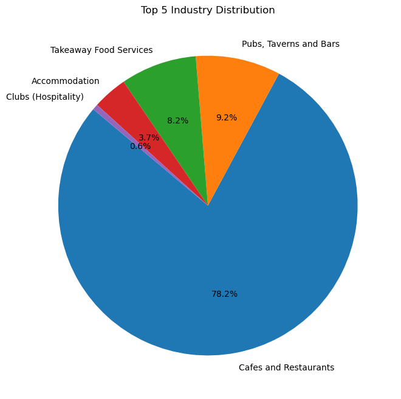

```python
# Get the top 5 most common Industry descriptions
top_5_industries = cafes_restaurants_deduplicated['industry_anzsic4_description'].value_counts().nlargest(5)

# Display the top 5 industries
print("Top 5 Industry (ANZSIC4) Descriptions:")
print(top_5_industries)

# Pie chart for the top 5 Industry Description distribution
plt.figure(figsize=(8, 8))
plt.pie(top_5_industries, labels=top_5_industries.index, autopct='%1.1f%%', startangle=140)
plt.title('Top 5 Industry Distribution')
plt.show()
```

### Top 5 Industry Distribution

This pie chart illustrates the top 5 most common industry descriptions based on the **ANZSIC4** classification in the **Cafes and Restaurants** dataset.

#### Key Points:

- **Cafes and Restaurants** dominate with **78.2%** of the dataset.
- **Pubs, Taverns and Bars** make up **9.2%** of the dataset.
- **Takeaway Food Services** account for **8.2%**.
- **Accommodation** and **Clubs (Hospitality)** contribute **3.7%** and **0.6%** respectively.

This distribution gives a clear view of the prevalent business types in the dataset, with Cafes and Restaurants making up the vast majority.

### Interactive Map Visualization for Bars and Pubs

```python
# Ensure latitude and longitude columns
bars_pubs_deduplicated[['latitude', 'longitude']] = bars_pubs_deduplicated['location'].str.split(',', expand=True)
bars_pubs_deduplicated['latitude'] = pd.to_numeric(bars_pubs_deduplicated['latitude'])
bars_pubs_deduplicated['longitude'] = pd.to_numeric(bars_pubs_deduplicated['longitude'])

# Convert DataFrame to GeoDataFrame
gdf_bars_pubs = gpd.GeoDataFrame(
    bars_pubs_deduplicated,
    geometry=gpd.points_from_xy(bars_pubs_deduplicated.longitude, bars_pubs_deduplicated.latitude),
    crs="EPSG:4326"
)

# Remove invalid or empty geometries
gdf_bars_pubs = gdf_bars_pubs[~gdf_bars_pubs['geometry'].is_empty]

# Define the interactive map function
def update_map_bars(trading_name):
    clear_output(wait=True)
    melbourne_map = folium.Map(location=[-37.8136, 144.9631], zoom_start=12)
    marker_cluster = MarkerCluster().add_to(melbourne_map)

    if trading_name == "All Locations":
        for idx, row in gdf_bars_pubs.iterrows():
            folium.CircleMarker(
                location=[row.geometry.y, row.geometry.x],
                radius=3,
                color='blue',
                fill=True,
                fill_color='blue',
                popup=f"Trading Name: {row['trading_name']}, Patrons: {row['number_of_patrons']}"
            ).add_to(marker_cluster)
    else:
        selected_gdf = gdf_bars_pubs[gdf_bars_pubs['trading_name'] == trading_name]
        for idx, row in selected_gdf.iterrows():
            folium.CircleMarker(
                location=[row.geometry.y, row.geometry.x],
                radius=8,
                color='red',
                fill=True,
                fill_color='red',
                popup=f"Trading Name: {row['trading_name']}, Patrons: {row['number_of_patrons']}"
            ).add_to(marker_cluster)

    display(melbourne_map)

# Create the dropdown widget
trading_name_dropdown_bars = widgets.Dropdown(
    options=["All Locations"] + list(gdf_bars_pubs['trading_name'].unique()),
    description='Select Bar/Pub:'
)

# Link the dropdown to the map update function
widgets.interact(update_map_bars, trading_name=trading_name_dropdown_bars)
```

```
interactive(children=(Dropdown(description='Select Bar/Pub:', options=('All Locations', 'Nomads Industry Backp…
```

```
<function __main__.update_map_bars(trading_name)>
```

### Interactive Map Visualization for Bars and Pubs

This code generates an interactive map visualization for the **Bars and Pubs** dataset, displaying the locations of venues and allowing users to explore specific bars/pubs.

#### Key Steps:

1. **Extract Latitude and Longitude**: The `location` column is split to separate the latitude and longitude values, which are then converted to numeric data types.
2. **Convert to GeoDataFrame**: The dataset is converted into a GeoDataFrame using **GeoPandas** to facilitate mapping operations.
3. **Filter Invalid Geometries**: Invalid or empty geometries are removed to ensure only valid points are mapped.
4. **Interactive Map Creation**: The map is generated using **Folium**, with CircleMarkers representing each bar/pub.
   - Blue markers indicate all locations.
   - Red markers highlight selected locations.
   - Each marker contains a popup showing the venue's trading name and the number of patrons.

This interactive map provides a dynamic and visual way to explore bar and pub locations across Melbourne, enhancing the data exploration experience.

### Interactive Map Visualization for Cafes and Restaurants

```python
# Ensure latitude and longitude columns
cafes_restaurants_deduplicated[['latitude', 'longitude']] = cafes_restaurants_deduplicated['location'].str.split(',', expand=True)
cafes_restaurants_deduplicated['latitude'] = pd.to_numeric(cafes_restaurants_deduplicated['latitude'])
cafes_restaurants_deduplicated['longitude'] = pd.to_numeric(cafes_restaurants_deduplicated['longitude'])

# Convert DataFrame to GeoDataFrame
gdf_cafes_restaurants = gpd.GeoDataFrame(
    cafes_restaurants_deduplicated,
    geometry=gpd.points_from_xy(cafes_restaurants_deduplicated.longitude, cafes_restaurants_deduplicated.latitude),
    crs="EPSG:4326"
)

# Remove invalid or empty geometries
gdf_cafes_restaurants = gdf_cafes_restaurants[~gdf_cafes_restaurants['geometry'].is_empty]

# Define the interactive map function
def update_map_cafes(trading_name):
    clear_output(wait=True)
    melbourne_map = folium.Map(location=[-37.8136, 144.9631], zoom_start=12)
    marker_cluster = MarkerCluster().add_to(melbourne_map)

    if trading_name == "All Locations":
        for idx, row in gdf_cafes_restaurants.iterrows():
            folium.CircleMarker(
                location=[row.geometry.y, row.geometry.x],
                radius=3,
                color='green',
                fill=True,
                fill_color='green',
                popup=f"Trading Name: {row['trading_name']}, Seats: {row['number_of_seats']}"
            ).add_to(marker_cluster)
    else:
        selected_gdf = gdf_cafes_restaurants[gdf_cafes_restaurants['trading_name'] == trading_name]
        for idx, row in selected_gdf.iterrows():
            folium.CircleMarker(
                location=[row.geometry.y, row.geometry.x],
                radius=8,
                color='orange',
                fill=True,
                fill_color='orange',
                popup=f"Trading Name: {row['trading_name']}, Seats: {row['number_of_seats']}"
            ).add_to(marker_cluster)

    display(melbourne_map)

# Create the dropdown widget
trading_name_dropdown_cafes = widgets.Dropdown(
    options=["All Locations"] + list(gdf_cafes_restaurants['trading_name'].unique()),
    description='Select Cafe/Restaurant:'
)

# Link the dropdown to the map update function
widgets.interact(update_map_cafes, trading_name=trading_name_dropdown_cafes)
```

```
interactive(children=(Dropdown(description='Select Cafe/Restaurant:', options=('All Locations', "Abbot's Seafo…
```

```
<function __main__.update_map_cafes(trading_name)>
```

### Interactive Map Visualization for Cafes and Restaurants

This code generates an interactive map visualization for the **Cafes and Restaurants** dataset, allowing users to explore the seating capacity of venues.

#### Key Steps:

1. **Extract Latitude and Longitude**: The `location` column is split to separate latitude and longitude values, which are then converted into numeric data types.
2. **Convert to GeoDataFrame**: The dataset is converted into a GeoDataFrame using **GeoPandas** to facilitate spatial mapping operations.
3. **Filter Invalid Geometries**: Invalid or empty geometries are removed to ensure only valid points are mapped.
4. **Interactive Map Creation**: The map is generated using **Folium**, with CircleMarkers representing each cafe/restaurant.
   - Green markers represent all locations.
   - Orange markers highlight specific selected locations.
   - Each marker contains a popup showing the trading name and number of seats for the venue.
5. **Dropdown for Venue Selection**: A dropdown widget allows users to filter and display a specific cafe or restaurant, enhancing the interactivity of the map.

This interactive map provides an intuitive way to visualize cafe and restaurant locations along with their seating capacities across Melbourne.

### Merge Datasets

```python
# Perform an inner merge based on 'property_id'
merged_df = pd.merge(bars_pubs_deduplicated, cafes_restaurants_deduplicated, on='property_id', how='inner', suffixes=('_bars', '_cafes'))

# Display the first few rows of the merged dataset
print(merged_df.head())

# Display basic information of the merged dataset
print(merged_df.info())
```

```
   census_year_bars  property_id                      building_address_bars  \
0              2009       100160    196-200 A'Beckett Street MELBOURNE 3000
1              2002       100514  204-206 Arden Street NORTH MELBOURNE 3051
2              2005       100727              5-9 Bank Place MELBOURNE 3000
3              2016       100730            12-16 Bank Place MELBOURNE 3000
4              2002       101023            25 Bennetts Lane MELBOURNE 3000

                           trading_name_bars  number_of_patrons  \
0                Nomads Industry Backpackers                200
1  North Melbourne Football Club Social Club                210
2                               Mitre Tavern                300
3                      Melbourne Savage Club                 90
4                    Bennetts Lane Jazz Club                360

                             location_bars  latitude_bars  longitude_bars  \
```

[output cut: 65 more lines]

### Merge Datasets

This step involves merging the **Bars and Pubs** and **Cafes and Restaurants** datasets based on the common column `property_id`.

#### Key Steps:

1. **Perform an Inner Join**: The datasets are merged using an inner join on the `property_id` column. This ensures that only properties present in both datasets are included in the merged dataset.
2. **Inspect the Merged Data**: The first few rows of the merged dataset are displayed, along with basic information about the dataset structure, such as the number of entries and columns.

The merged dataset includes information from both bars/pubs and cafes/restaurants, making it possible to analyze properties that serve as both a bar and a restaurant or compare their features.

### Correlation Matrix for Seating Capacity and Patron Capacity

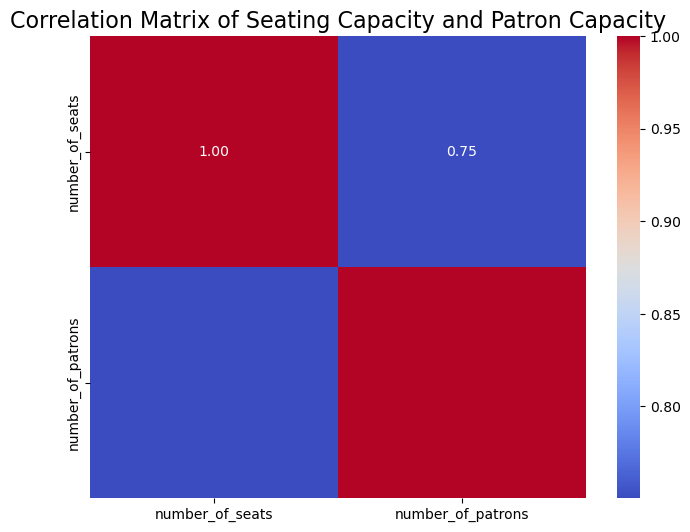

```
Pearson correlation coefficient between seating capacity and patron capacity: 0.7504581760423324
```

```python
# Calculate the Pearson correlation coefficient
correlation = merged_df['number_of_seats'].corr(merged_df['number_of_patrons'])

# Calculate the correlation matrix
correlation_matrix = merged_df[['number_of_seats', 'number_of_patrons']].corr()

# Plot the correlation matrix using a heatmap
plt.figure(figsize=(8, 6))
sns.heatmap(correlation_matrix, annot=True, cmap='coolwarm', fmt=".2f")

# Customize the title
plt.title("Correlation Matrix of Seating Capacity and Patron Capacity", fontsize=16)

# Display the plot
plt.show()

print(f"Pearson correlation coefficient between seating capacity and patron capacity: {correlation}")
```

### Correlation Matrix for Seating Capacity and Patron Capacity

This step visualizes the correlation between **seating capacity** and **patron capacity** for properties that serve as both a bar/pub and a cafe/restaurant.

#### Key Steps:

1. **Calculate Pearson Correlation**: The Pearson correlation coefficient between the number of seats and the number of patrons is calculated. This measures the linear relationship between seating capacity and patron capacity.
2. **Generate Correlation Matrix**: A correlation matrix is created to visually display the correlation values between the two variables.
3. **Plot the Heatmap**: The correlation matrix is plotted using a heatmap to visually represent the strength of the correlation.
   - A correlation of **1.00** on the diagonal indicates a perfect correlation with itself.
   - A correlation of **0.75** between the number of seats and patrons suggests a strong positive relationship.

This matrix helps to understand how closely seating capacity relates to the number of patrons, which is useful for operational planning and resource allocation.

### Relationship Between Seating Capacity and Patron Capacity

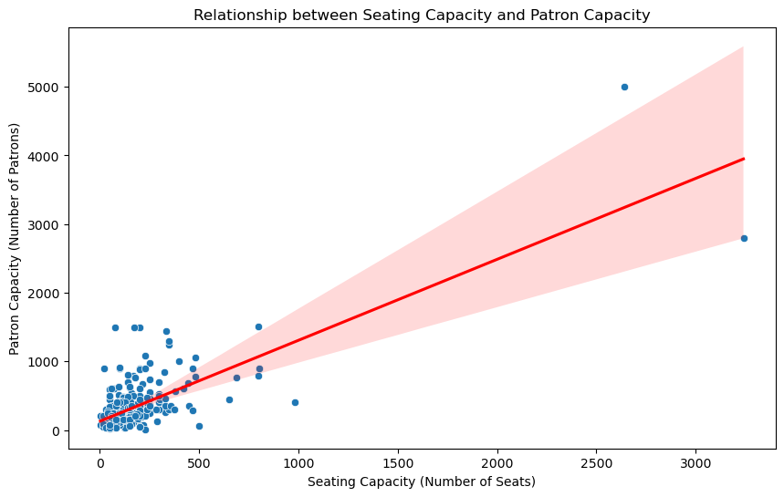

```python
# Create a scatter plot
plt.figure(figsize=(10, 6))
sns.scatterplot(x='number_of_seats', y='number_of_patrons', data=merged_df)

# Add a regression line to highlight the trend
sns.regplot(x='number_of_seats', y='number_of_patrons', data=merged_df, scatter=False, color='red')

plt.title('Relationship between Seating Capacity and Patron Capacity')
plt.xlabel('Seating Capacity (Number of Seats)')
plt.ylabel('Patron Capacity (Number of Patrons)')
plt.show()
```

### Relationship Between Seating Capacity and Patron Capacity

This scatter plot visualizes the relationship between **seating capacity** (number of seats) and **patron capacity** (number of patrons) for venues that serve as both cafes/restaurants and bars/pubs.

#### Key Points:

- Each point on the scatter plot represents a venue, with the x-axis showing the number of seats and the y-axis showing the number of patrons.
- A **regression line** is added to highlight the trend between seating capacity and patron capacity. The positive slope indicates a general trend that as seating capacity increases, patron capacity tends to increase as well.
- The shaded area around the regression line represents the **confidence interval**, showing the range within which the true relationship between seating capacity and patron capacity lies.
- **Correlation Coefficient**: The Pearson correlation coefficient between seating capacity and patron capacity is **0.75**. This indicates a strong positive relationship, meaning that as the seating capacity of an establishment increases, the patron capacity generally increases as well.
- **Scatter Plot**: The scatter plot shows a clear upward trend, reinforcing the positive relationship between seating and patron capacities. Most data points cluster together with a few outliers, particularly at higher capacities.
- **Regression Line**: The red regression line represents the best-fit line through the data points, highlighting the overall trend. The shaded area around the line shows the confidence interval, which widens as seating capacity increases. This suggests some variability in the relationship at higher capacities.

This plot demonstrates a positive correlation between seating and patron capacities, which aligns with expectations that larger venues accommodate more patrons.

### Interactive map for Merged Bars, Pubs, Restaurants and Cafes

```python
# Function to update the map based on dropdown selection
def update_map(trading_name):
    # Clear the previous output
    clear_output(wait=True)

    # Create the map
    if trading_name == "All Locations":
        updated_map = folium.Map(location=[-37.8136, 144.9631], zoom_start=12)
        for _, row in merged_df.iterrows():
            location = [float(coord) for coord in row['location_bars'].split(', ')]
            popup_text = f"{row['trading_name_bars']}: Seats {row['number_of_seats']}, Patrons {row['number_of_patrons']}"
            folium.Marker(
                location=location,
                popup=popup_text,
                tooltip=row['trading_name_bars']
            ).add_to(updated_map)
    else:
        selected_row = merged_df[merged_df['trading_name_bars'] == trading_name].iloc[0]
        location = [float(coord) for coord in selected_row['location_bars'].split(', ')]
        popup_text = f"{selected_row['trading_name_bars']}: Seats {selected_row['number_of_seats']}, Patrons {selected_row['number_of_patrons']}"
        updated_map = folium.Map(location=location, zoom_start=15)
        folium.Marker(
            location=location,
            popup=popup_text,
            tooltip=selected_row['trading_name_bars']
        ).add_to(updated_map)

    # Display the updated map
    display(updated_map)

# Create a dropdown for selecting the establishment, with an option for "All Locations"
dropdown = widgets.Dropdown(
    options=["All Locations"] + list(merged_df['trading_name_bars'].unique()),
    description='Select Place:',
    disabled=False,
)

# Link the dropdown to the update_map function
widgets.interact(update_map, trading_name=dropdown)
```

```
interactive(children=(Dropdown(description='Select Place:', options=('All Locations', 'Nomads Industry Backpac…
```

```
<function __main__.update_map(trading_name)>
```

### Interactive Map for Merged Bars, Pubs, Restaurants, and Cafes

This code generates an interactive map that displays the merged data from **Bars and Pubs** and **Cafes and Restaurants**, allowing users to visualize and explore seating and patron capacities across locations.

#### Key Features:

1. **Dropdown for Location Selection**: A dropdown widget is provided to select either "All Locations" or a specific establishment. This allows for a more detailed exploration of individual venues.
2. **Map Creation**:
   - If "All Locations" is selected, markers for all venues are displayed on the map.
   - If a specific venue is selected, a marker for that particular location is displayed.
3. **Marker Details**: Each marker shows a popup with the **trading name**, **number of seats**, and **number of patrons** for the venue.
4. **Interactive Visualization**: The map is rendered interactively using **Folium**, and the dropdown selection dynamically updates the map display.

This interactive map provides a comprehensive way to visualize the combined data of bars, pubs, cafes, and restaurants, helping users explore different locations and their seating/patron capacities.

### Changes in seating capacity and patron capacity

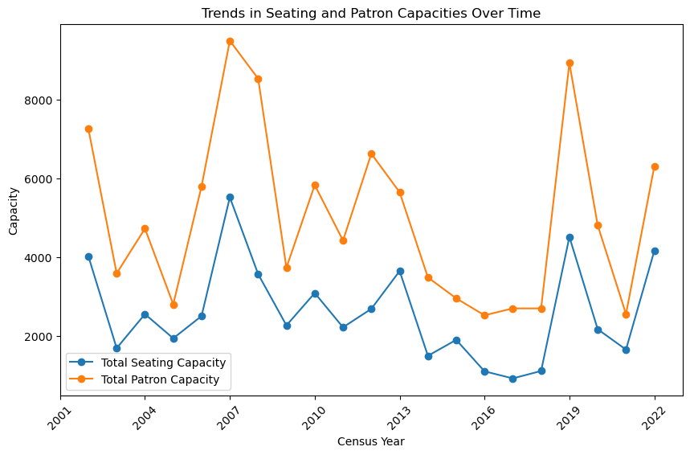

```python
# Group data by census year and sum capacities
time_series = merged_df.groupby('census_year_bars').agg({'number_of_seats': 'sum', 'number_of_patrons': 'sum'}).reset_index()

# Plot the trends over time with whole number years on the x-axis
plt.figure(figsize=(10, 6))
plt.plot(time_series['census_year_bars'], time_series['number_of_seats'], label='Total Seating Capacity', marker='o')
plt.plot(time_series['census_year_bars'], time_series['number_of_patrons'], label='Total Patron Capacity', marker='o')
plt.title('Trends in Seating and Patron Capacities Over Time')
plt.xlabel('Census Year')
plt.ylabel('Capacity')
plt.xticks(time_series['census_year_bars'], rotation=45)
plt.gca().xaxis.set_major_locator(mticker.MaxNLocator(integer=True))
plt.legend()
plt.show()
```

### Changes in Seating Capacity and Patron Capacity Over Time

This plot visualizes the trends in **seating capacity** and **patron capacity** across different census years based on the merged dataset.

This analysis highlights the dynamic nature of the hospitality sector in Melbourne, with periods of growth followed by contractions, particularly in terms of patron capacity. Further investigation could be conducted to explore the underlying causes of these trends.

### Boxplot for Seating Capacity Amoung Different Industries

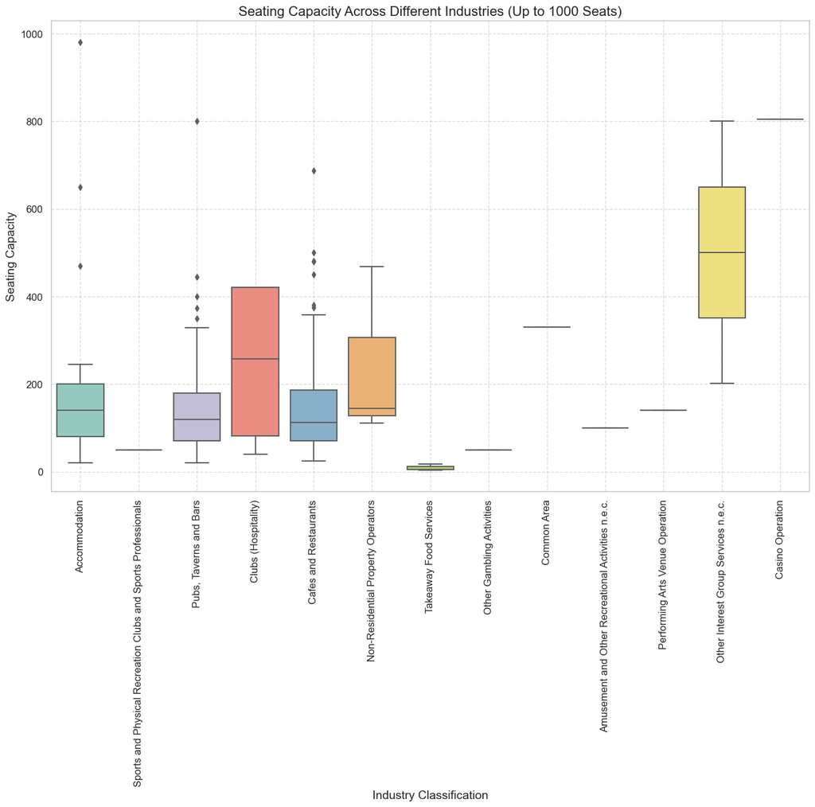

```python
# Filter the dataframe to include only entries with seating capacities up to 1000
filtered_df = merged_df[merged_df['number_of_seats'] <= 1000]

# Set the style and context for the plot
sns.set(style="whitegrid")
plt.figure(figsize=(16, 10))

# Customize the boxplot with a color palette and gridlines
sns.boxplot(
    x='industry_anzsic4_description',
    y='number_of_seats',
    data=filtered_df,
    palette="Set3"
)

# Title and labels
plt.title('Seating Capacity Across Different Industries (Up to 1000 Seats)', fontsize=16)
plt.xticks(rotation=90, fontsize=12)
plt.yticks(fontsize=12)
plt.xlabel('Industry Classification', fontsize=14)
plt.ylabel('Seating Capacity', fontsize=14)

# Add gridlines for better readability
plt.grid(True, linestyle='--', alpha=0.7)

# Display the plot
plt.show()
```

### Boxplot for Seating Capacity Amoung Different Industries

The boxplot visualizes the distribution of seating capacities across different industries, limited to those with a seating capacity of up to 1000 seats.

This analysis provides insights into how seating capacities vary across different sectors within the hospitality industry, highlighting the differences in operational scale and customer service models across these sectors.

### Seating Capacity by Industry and Seating Type

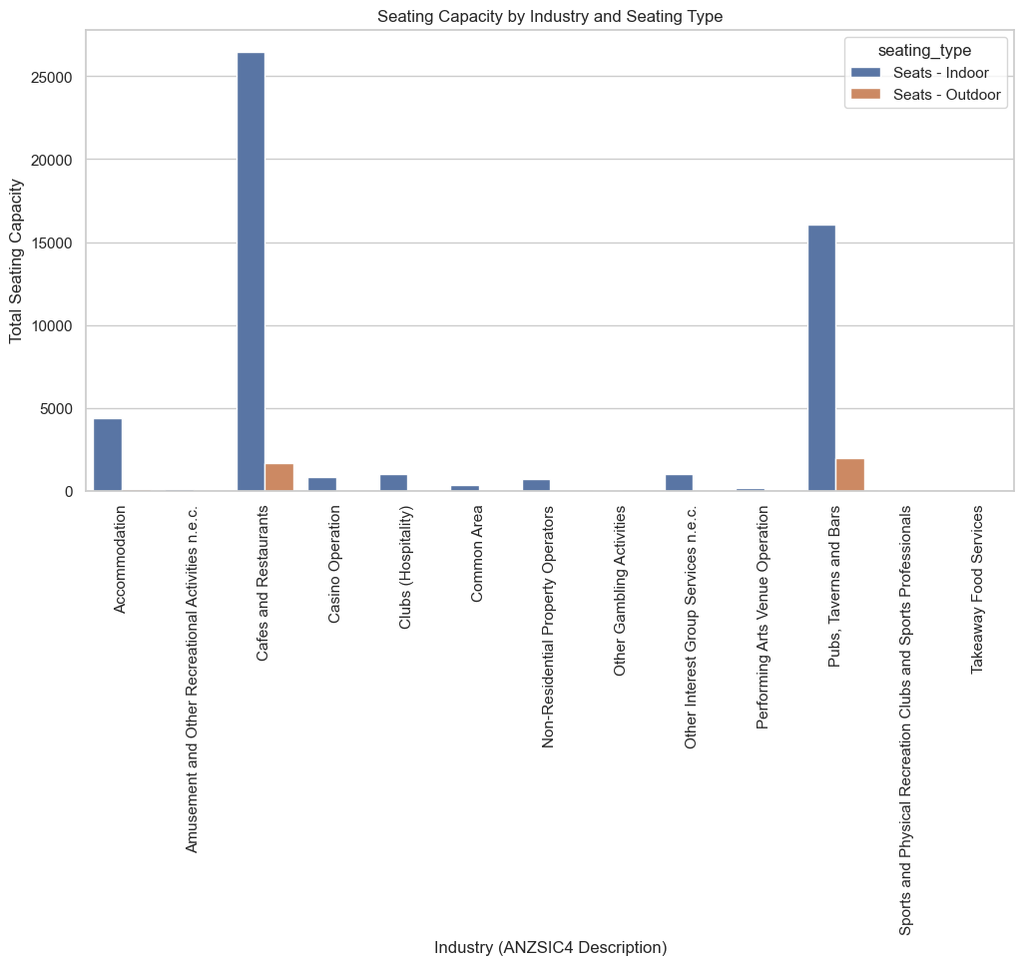

```python
# Group by industry classification and seating type, then sum capacities
industry_seating = merged_df.groupby(['industry_anzsic4_description', 'seating_type']).agg({'number_of_seats': 'sum'}).reset_index()

# Plot the industry vs. seating type
plt.figure(figsize=(12, 6))
sns.barplot(x='industry_anzsic4_description', y='number_of_seats', hue='seating_type', data=industry_seating)
plt.title('Seating Capacity by Industry and Seating Type')
plt.xlabel('Industry (ANZSIC4 Description)')
plt.ylabel('Total Seating Capacity')
plt.xticks(rotation=90)
plt.show()
```

### Seating Capacity by Industry and Seating Type

This bar plot shows the total seating capacity categorized by **industry classification** and **seating type** (indoor vs. outdoor).

#### Key Steps:

1. **Group by Industry and Seating Type**: The data is grouped by `industry_anzsic4_description` and `seating_type`, and the total seating capacity is summed for each group.
2. **Plot the Data**: The seating capacity for each industry is visualized, with a distinction between indoor and outdoor seating using different colors.
   - **Blue** bars represent indoor seating capacity.
   - **Orange** bars represent outdoor seating capacity.

#### Observations:

- **Cafes and Restaurants** dominate the total seating capacity, especially for indoor seating.
- **Pubs, Taverns, and Bars** also show a significant indoor seating capacity, with a smaller proportion of outdoor seating.
- Almost all other industries have smaller seating capacities.

This plot helps to compare seating capacities across different industries and seating types, providing insights into venue sizes and seating arrangements.

## Identify potential locations for starting a new restaurant, cafe, bar, or pub based on the seating capacity analysis

### Filter Data Based on Business Type

```python
# Filter the data for specific industries
restaurants_cafes_df = merged_df[merged_df['industry_anzsic4_description'].isin(['Cafes and Restaurants', 'Pubs, Taverns and Bars'])]

# Show the filtered data
print(restaurants_cafes_df.head())
```

```
   census_year_bars  property_id               building_address_bars  \
2              2005       100727       5-9 Bank Place MELBOURNE 3000
4              2002       101023     25 Bennetts Lane MELBOURNE 3000
5              2002       101109  39-43 Bourke Street MELBOURNE 3000
6              2012       101113  59-63 Bourke Street MELBOURNE 3000
7              2017       101116  79-85 Bourke Street MELBOURNE 3000

         trading_name_bars  number_of_patrons  \
2             Mitre Tavern                300
4  Bennetts Lane Jazz Club                360
5           Spleen Central                100
6           Madam Brussels                256
7             Good Heavens                400

                             location_bars  latitude_bars  longitude_bars  \
```

[output cut: 33 more lines]

### Analyze the Distribution of Seating Capacities

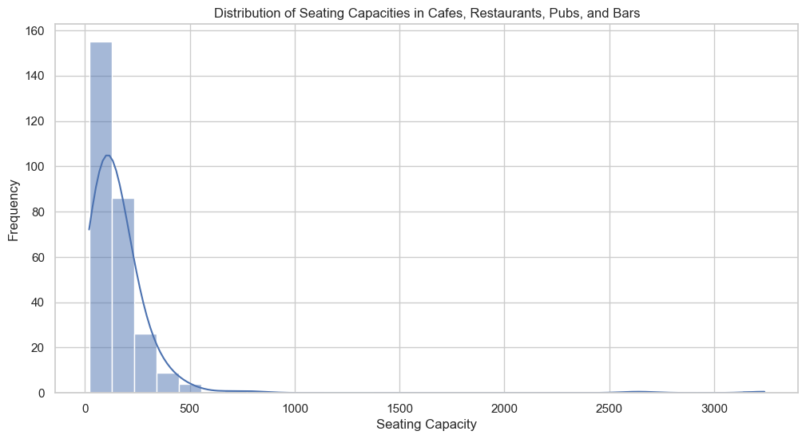

```python
# Plot distribution of seating capacities
plt.figure(figsize=(12, 6))
sns.histplot(restaurants_cafes_df['number_of_seats'], bins=30, kde=True)
plt.title('Distribution of Seating Capacities in Cafes, Restaurants, Pubs, and Bars')
plt.xlabel('Seating Capacity')
plt.ylabel('Frequency')
plt.show()
```

### Identify Potential Locations for Starting a New Restaurant, Cafe, Bar, or Pub Based on the Seating Capacity Analysis

#### Filter Data Based on Business Type

In this step, we filter the merged dataset to include only relevant business types: **Cafes and Restaurants** and **Pubs, Taverns, and Bars**. The filtered data includes key information such as the number of patrons, seating type, and seating capacity.

#### Analyze the Distribution of Seating Capacities

This histogram visualizes the distribution of seating capacities for the filtered businesses.

- The distribution is right-skewed, with the majority of businesses having seating capacities below 500.
- A small number of businesses have seating capacities higher than 500, with a few outliers exceeding 2000 seats.

These insights can help identify gaps in the market for businesses of specific seating capacities, providing guidance for potential locations to start a new venue.

### Identify High-Capacity Locations

```python
# Group by location and calculate total seating capacity for each
location_seating_capacity = restaurants_cafes_df.groupby('building_address_cafes')['number_of_seats'].sum().reset_index()

# Sort by seating capacity to identify high-capacity locations
high_capacity_locations = location_seating_capacity.sort_values(by='number_of_seats', ascending=False)

# Display top locations
print(high_capacity_locations.head(10))
```

```
                         building_address_cafes  number_of_seats
31             120 Brunton Avenue JOLIMONT 3002             3240
35     122-148 Harbour Esplanade DOCKLANDS 3008             2640
84             2 Swanston Street MELBOURNE 3000              880
69       183-265 La Trobe Street MELBOURNE 3000              867
227            557 St Kilda Road MELBOURNE 3004              800
83   2 Convention Centre Place SOUTH WHARF 3006              500
100   221 Little Lonsdale Street MELBOURNE 3000              481
196      425-427 Docklands Drive DOCKLANDS 3008              480
94           21-31 Market Street MELBOURNE 3000              450
49     143-175 Harbour Esplanade DOCKLANDS 3008              444
```